# Oefeningen week 5

Jelle Becirspahic

### Opdracht 1

*Download de meest recente lijst met aardbevingen en geef de 5 plaatsen met de zwaarste aardbevingen.*

```r
all_induced <- read.csv("all_induced.csv")
highest_values <- order(all_induced$MAG, decreasing = T)[1:5]
all_induced$LOCATION[highest_values]
```

```
[1] Huizinge    Bergen      Westeremden
[4] Roswinkel   Zeerijp
180 Levels: 't Zandt Alkmaar Amen ... Zuidwolde
```

### Opdracht 2

*In welke tien plaatsen hebben zich de meeste opgewekte aardbevingen voorgedaan met een sterkte van meer dan 1.5?*

```r
waarde <- order(all_induced$MAG, decreasing = T)[sort(all_induced$MAG, decreasing = T) > 1.5]
names(sort(table(all_induced$LOCATION[waarde]), decreasing = T)[1:10])
```

```
 [1] "Roswinkel"   "Zeerijp"     "Appingedam"  "Wirdum"
 [5] "Garrelsweer" "Westeremden" "Noordzee"    "Emmen"
 [9] "Loppersum"   "Middelstum"
```

### Opdracht 3

*Is er in de gemeente Loppersum een trend in de frequentie van het optreden van aardbevingen zichtbaar?*

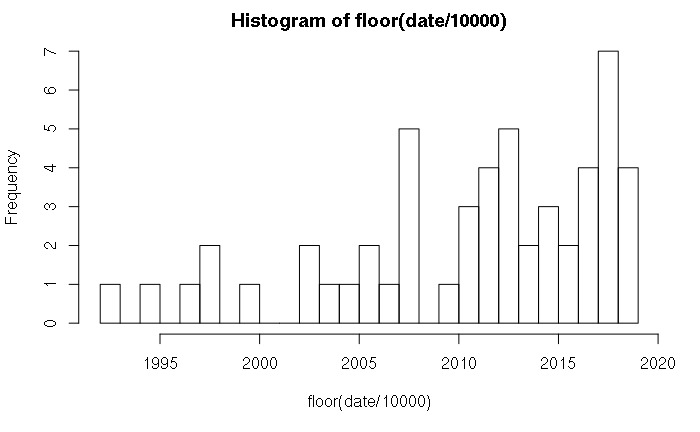

```r
indices <- which(all_induced$LOCATION == "Loppersum")
date <- all_induced$YYMMDD[indices]
hist(floor(date/10000), breaks = 35)
```

### Opdracht 4

*De dataset bevat regels met metingen aan verschillende soorten irissen. Gemeten zijn de lengte en de breedte van de kelk- en de bloemblaadjes. Welke van deze gegevens kun je gebruiken om een iris die je in de tuin hebt te determineren? Maak een figuur c.q. de figuren die je hiervoor nodig hebt.*

```r
summary(iris)
```

```
  Sepal.Length    Sepal.Width     Petal.Length    Petal.Width
 Min.   :4.300   Min.   :2.000   Min.   :1.000   Min.   :0.100
 1st Qu.:5.100   1st Qu.:2.800   1st Qu.:1.600   1st Qu.:0.300
 Median :5.800   Median :3.000   Median :4.350   Median :1.300
 Mean   :5.843   Mean   :3.057   Mean   :3.758   Mean   :1.199
 3rd Qu.:6.400   3rd Qu.:3.300   3rd Qu.:5.100   3rd Qu.:1.800
 Max.   :7.900   Max.   :4.400   Max.   :6.900   Max.   :2.500
       Species
 setosa    :50
 versicolor:50
 virginica :50
```

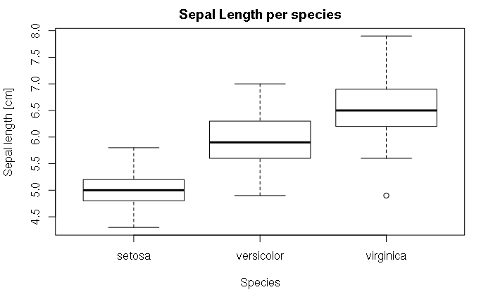

```r
plot(iris$Species, iris$Sepal.Length, main="Sepal Length per species", ylab="Sepal length [cm]", xlab = "Species")
```

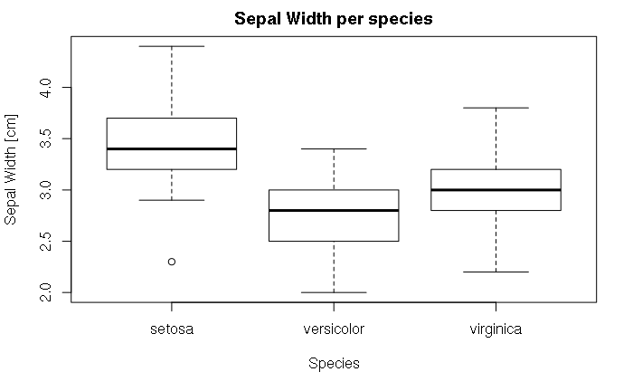

```r
plot(iris$Species, iris$Sepal.Width, main="Sepal Width per species", ylab="Sepal Width [cm]", xlab = "Species")
```

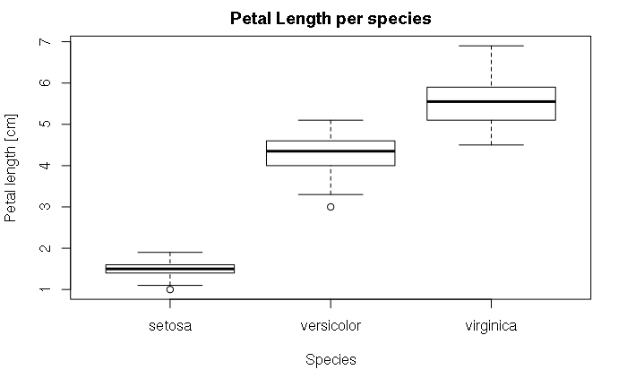

```r
plot(iris$Species, iris$Petal.Length, main="Petal Length per species", ylab="Petal length [cm]", xlab = "Species")
```

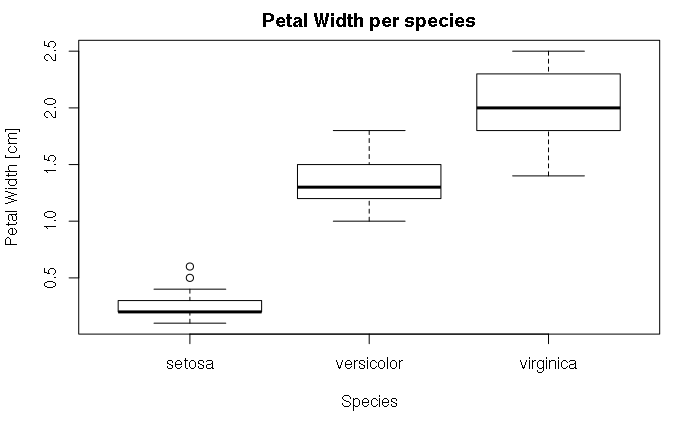

```r
plot(iris$Species, iris$Petal.Width, main="Petal Width per species", ylab="Petal Width [cm]", xlab = "Species")
```

Bij de blad lengte is het grootste verschil te zien tussen de verschillende soorten. Hier zou dus het makkelijkst onderscheid in te maken zijn.

### Opdracht 5

*Geef in een codeblok de R-code waarmee je een .xls in kunt lezen in R*

```r
library("readxl")
my.data <- read_excel("my_file.xls")
```

```
Error: `path` does not exist: ‘my_file.xls’
```

### Opdracht 6

*Je kunt een .xls ook converteren naar het .csv formaat. Leg uit (code en tekst) hoe je dit m.b.v. Python doet.*

```python
import xlrd
import csv

  def csv_from_excel():
    wb = xlrd.open_workbook('your_workbook.xls')
    sh = wb.sheet_by_name('Sheet1')
    your_csv_file = open('your_csv_file.csv', 'wb')
    wr = csv.writer(your_csv_file, quoting=csv.QUOTE_ALL)

    for rownum in xrange(sh.nrows):
        wr.writerow(sh.row_values(rownum))

    your_csv_file.close()
```

### Opdracht 7

*Je kunt een .xls ook converteren naar het .csv formaat. Leg uit (code) hoe je dit m.b.v. LibreOffice kunt doen.*

libreoffice –headless –convert-to csv “my_file.xls”

### Opdracht 8

*Pas het commando uit opdracht 7 zo aan dat je alle .xls bestanden in één directory tegelijk converteert.*

libreoffice –headless –convert-to csv *.xls

### Opdracht 9

*In /homes/arne/tmp/data/ staan een aantal .xls bestanden die gegevens over een batterij zonnecellen bevatten. I staat voor stroomsterkte in Ampere V staat voor spanning in Volt F staat voor de (wisselstroom)frequentie in Herz. Pac staat voor het op dat moment afgegeven vermogen in Watt. pv staat voor ‘photo voltaic’ dus opgewekt door de zonnecellen. Er zijn hier twee groepen voor. ac staat voor ‘alternating current’ dus dit wordt doorgegeven aan het stroomnetwerk. Hiervoor zijn er 3 fasen. De overige velden zouden voor zich moeten spreken.* *Copiëer deze data naar een directory in je eigen home en lees ze in in R.*

```r
read.xls.self <- function(x){
  read_xls(x, col_names = T, skip = 2)
}
my.data <- lapply(Sys.glob("*.xls"), read.xls.self)
```

[output not shown]

```r
names(my.data) <- c(1:length(my.data))
```

### Opdracht 10

*Gebruik de gegevens die je in opdracht 9 ingelezen hebt. Maak één figuur waarin je het totaal aantal KWh wat gegenereerd is uitzet tegen de tijd (datum). Gebruik hiervoor de gegevens uit alle bestanden. Laat de datum zien in het formaat yyyymmdd.*

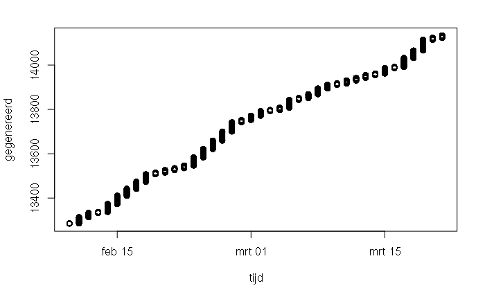

```r
tijd <- numeric(0)
gegenereerd <- numeric(0)
for(num in 1:length(my.data)){
  tijd <- c(tijd, my.data[[num]]$Time)
  gegenereerd <- c(gegenereerd, my.data[[num]]$`Total Generation(kWh)`)
  rm(num)
}
tijd <- as.Date(tijd, format = "%m/%d/%Y")
plot(tijd, gegenereerd)
```